# First failed plot

B. Slangen

2/15/2021

For my first representation I have tried to create an overview of the different versions of cover songs in my Corpus. Sadly I have had some trouble getting the artists names from Spotify which made me unable to give information about this. Even a more major issue I faced was the group_by function, which can only group songs that have the exact same title. Cover songs sadly do not always have exctly the same title. In the graph below you see an attempt to show a basic distribution of my Corpus based on the energy (x-axis) and valence (y-axis). I chose these two values to give an insight in the overal feel of a song according to spotify. With this I attempted to create a feeling of how far the feel of the cover songs was apart from the original (and possibly other covers of the same song), to give a stronger sense of the differences I attempted to draw lines between different versions of the same song.

```r
library(tidyverse)
library(spotifyr)
```

```r
Magnus_Corpus <- get_playlist_audio_features("", "61rge4nRNpMipwrZ1SojP7")
```

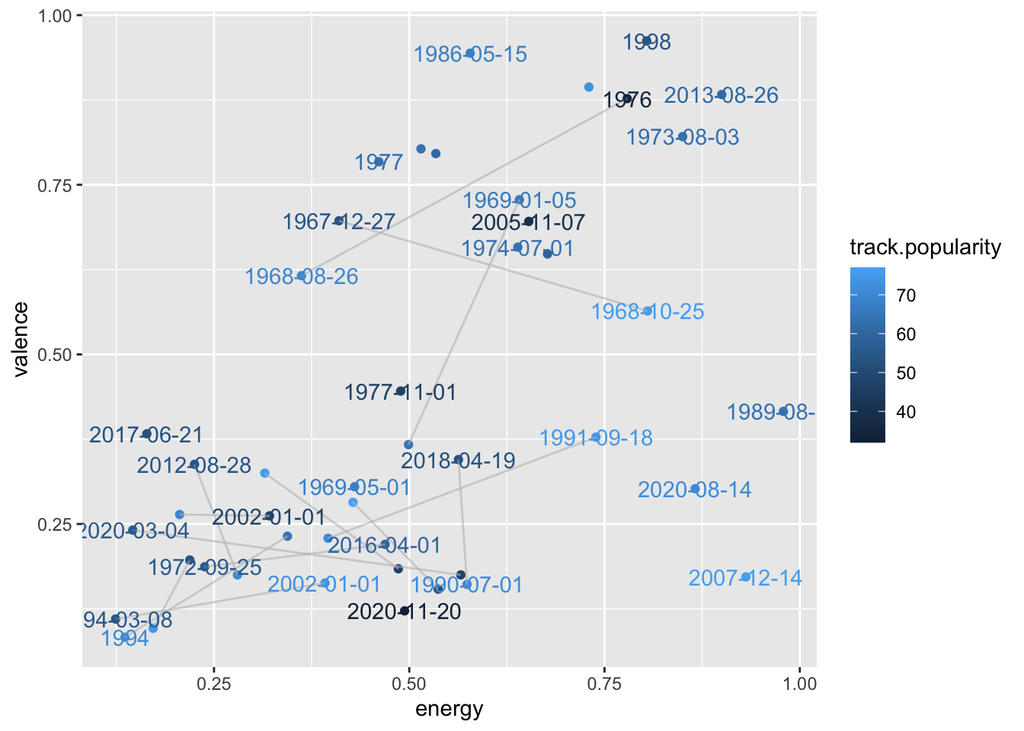

```r
# Zeroos <- get_playlist_audio_features("", "37i9dQZF1DX4o1oenSJRJd")
# Eighties <- get_playlist_audio_features("", "23xQYspGsaIsztrKTHM8cN")
#
# combined <-
#   bind_rows(
#     Zeroos %>% mutate(category = "Zeroos"),
#     Eighties %>% mutate(category = "Eighties")
#   )
# ggplot(combined, aes(x =energie , y =valence , color=playplist_name)) + geom_point
#
Ordered_magnus_corpus <- Magnus_Corpus[with(Magnus_Corpus, order(track.name)),]
ggplot(Ordered_magnus_corpus , aes(x =energy , y =valence, color =track.popularity, group = track.name,)) + geom_point() + geom_line(col = 'gray', alpha = 0.6) +   geom_text(
    aes(label=track.album.release_date),
    check_overlap = T
  )
```